# Large scale drivers of trophic interactions in the Chilean coast

Catalina A. Musrri

20-06-2020

## Clear the environment

```r
rm(list = ls())
```

## Load packages

*Before loading the packages install them using *install()**

```r
library(tidyverse)
library(summarytools)
library(tidyr)
library(dplyr)
library(readr)
library(vegan)
library(patchwork)
library(ggplot2)
library(gamm4)
library(pander)
```

## **Part 1:** Importing and examining data

In this part the data frames were inspected in order to check the variable names and types. In some situations the data set was slightly modified for better further manipulation of them.

### **1a)** Import data

```r
Environmental <- read.csv("Data/Environmental_variables.csv")
Metadata <- read.csv("Data/Metadata_lat2018-2019.csv")
Herbivory <- read.csv("Data/Herbivory_latitudinal2018-2019.csv")
Benthic <- read.csv("Data/Percent_cover.csv")
Phlorotannins <- read.csv("Data/Phlorotannins.csv")
Predation <- read.csv("Data/Predation_latitudinal2018-2019.csv")
Size <- read.csv("Data/Size_estimations.csv")
Transects <- read.csv("Data/Transect2018-2019.csv")
```

### **1b)** Inspect structure of data frames

1. Site metadata

```r
view(dfSummary(Metadata))

#Rename temperature variables to avoid confusion with replicate measures in Environmental data
Metadata <- rename(Metadata, Temperature_site = Temperature_C)
```

2. Environmental data

```r
view(dfSummary(Environmental))

Environmental <- Environmental %>%
  rename(D_oxygen_percent = X., D_oxygen_mgL = D_oxygen) %>% #Rename oxygen percent variable
  select(-Date,-Campaign,-Latitude) #Remove variables that are in Metadata
```

3. Benthic cover

```r
view(dfSummary(Benthic))
Benthic <- Benthic %>%
  select(-Date) #Remove variables that are in Metadata
```

4. Herbivory

```r
view(dfSummary(Herbivory))
Herbivory <- Herbivory %>%
  select(-Date,-Campaign,-Season) %>%# Remove variables that are in Metadata
  mutate(Consumed_proportion = (Initial_length_mm-Final_Length_mm)/Initial_length_mm)
```

```r
Herbivory <- mutate(Herbivory, Bait2 = case_when(Bait == "Lessonia_spicata" ~ "Lessonia sp.",
                                                 Bait == "Lessonia_berteroana" ~ "Lessonia sp."))
Herbivory <- mutate(Herbivory, Consumption = case_when(Consumed_proportion == 0 ~ 0,
                                              Consumed_proportion != 0 ~ 1))
```

5. Predation

```r
view(dfSummary(Predation))
Predation <- Predation %>%
  select(-Date,-Campaign,-Season)  %>%# Remove variables that are in Metadata
mutate(Consumed_proportion = (Initial_Individuals-Remaining_individuals)/Initial_Individuals, Consumed_individuals = Initial_Individuals-Remaining_individuals) #Add Consumed_proportion column
```

For future analysis it was necessary to create major categories for Bait (Squidpops vs Crabs) and Assay time (2 hours and 24 hours)

```r
Predation <- mutate(Predation, Bait2 = case_when(Bait == "Squidpops" ~ "Squidpops",
                                                 Bait != "Squidpops" ~ "Crabs"), Assay_time2 = case_when(Assay_time == "24" ~ "24",
                                                 Bait != "24" ~ "2"))
```

6. Phlorotannins

```r
view(dfSummary(Phlorotannins))
Phlorotannins <- Phlorotannins %>%
  select(-Date,-Latitude) # Remove variables that are in metadata
```

7. Size

```r
view(dfSummary(Size))
Size <- Size %>%
  select(-Date,-Campaign) # Remove variables that are in Metadata
```

8. Transects

```r
view(dfSummary(Transects))
Transects <- Transects %>%
  select(-Date,-Campaign) # Remove variables that are in Metadata
```

## **Part 2:** Manipulating datasets

In this section data sets are manipulated for future analysis. New data sets with means and combined with metadata and consumption are created.

### **2a)** Environmental data

1. Join Environmental data with metadata

```r
Environmental_metadata <- Environmental %>%
    left_join(Metadata, by = "Site")
```

2. Join Environmental data with consumption

First summarise environmental data per site

```r
Environmental_2 <- Environmental_metadata %>%
  group_by(Site, Latitude) %>%
  select(-D_oxygen_percent, -Conductivity_Ms, V_Visibility, -C_f, -C_i, -H_Visibility) #Keep only variables that will be used in the analysis

Environmental_sum_long <- Environmental_2 %>%
  gather(Env_Variable, Value, Temperature:RPM) %>%
  group_by(Site, Latitude, Env_Variable)%>%
  summarise(Mean_value = mean(Value, na.rm=T),n = n(), sd = sd(Value,na.rm=T), se = sd/sqrt(n))

Environmental_sum <- Environmental_sum_long %>%
  select(Site, Env_Variable, Mean_value) %>%
pivot_wider(names_from = Env_Variable, values_from = Mean_value,
              values_fill = 0)
```

Then, add environmental data to consumption

- Predation vs environmental data sets

```r
Predation_env <- Predation %>%
    left_join(Environmental_sum, by = "Site")
```

- Herbivory vs environmental data sets

```r
Herbivory_env <- Herbivory %>%
  left_join(Environmental_sum, by = "Site")
```

### *2b):* Benthic data

1. Join benthic data with metadata

```r
Benthic_metadata <- Benthic  %>%
    left_join(Metadata, by = "Site")
```

2. Calculate mean, sd, and se by group

```r
Benthic_mean <- Benthic_metadata %>%
  group_by(Site, Latitude, Type)%>%
  summarise(Mean_cover = mean(Coverage),n = n(), sd = sd(Coverage), se = sd/sqrt(n))
```

3. Join Environmental data with consumption

First, summarise benthic cover per site and change it to the wide format

```r
Benthic_sum_wide <- Benthic %>%
  group_by(Site, Type) %>%
  summarise(cover_mean = mean(Coverage)) %>%
  pivot_wider(names_from = Type, values_from = cover_mean,
              values_fill = 0)
Benthic_sum_wide_var <- select(Benthic_sum_wide, Site, Kelp, Understorey_algae)
```

Then, add benthic data to consumption

- Predation_env + Benthic summarised data

```r
Predation_2 <- Predation_env %>%
    left_join(Benthic_sum_wide_var, by = "Site")
```

- Herbivory_env + Benthic summarised data

```r
Herbivory_2 <- Herbivory_env %>%
  left_join(Benthic_sum_wide_var, by = "Site")
```

### **2c):** Fish length

1. Join Size data with metadata

```r
Size_metadata <- Size %>%
left_join(Metadata, by = c("Site"))
```

2. Calculate mean, sd and se per group

```r
Size_mean_sp<- Size_metadata %>%
  group_by(Site, Latitude, Species, Type)%>%
  summarise(mean_Size_sp = mean(Size_cm))
Size_mean <- Size_mean_sp %>%
   group_by(Site, Latitude, Type)%>%
  summarise(mean_Size = mean(mean_Size_sp),n = n(), sd = sd(mean_Size_sp), se = sd/sqrt(n))
```

3. Calculate mean of fish size and add it to consumption

```r
Size_mean_wide <- Size_mean_sp %>%
  filter(Type == "Fish") %>%
  group_by(Site, Type)%>%
  summarise(mean_Size = mean(mean_Size_sp)) %>%
  pivot_wider(names_from = Type, values_from = mean_Size,
              values_fill = 0) %>%
  rename(Fish_size = Fish)
```

Then, add fish length data to consumption

- Predation_env + fish size data

```r
Predation_3 <- Predation_2 %>%
    left_join(Size_mean_wide, by = "Site")
```

### **2d)** Species list (abundances and richness)

1. Add metadata to Transects data set

Summary of species from transects. Prepare data to calculate abundances and species richness

```r
#Join transects with metadata
Transect_metadata <- Transects %>%
left_join(Metadata, by = c("Site"))

Transect_sum <- Transect_metadata %>%
  filter(Method == "Transect") %>% #Select only data taken with visual transect method
  group_by(Site, Latitude, Census, Species) %>%
  summarise(Total_abundance = sum(Individuals))
```

2. Calculate abundances
- Calculate abundances by species

First, change data frame to the wide format

```r
Transect_wide <- Transect_sum %>%
   ungroup()  %>%
  pivot_wider(names_from = Species, values_from = Total_abundance,
              values_fill = 0)
```

Convert back to long format with Species and Abundance as columns. This will add rows with zeroes for all the species missing in each video

```r
Transect_long <- Transect_wide %>%
  gather(Species, Abundance, Anisotremus_scapularis:Labrisomus_philippii)

#Obtain mean abundance per site and method
Transect_mean <- Transect_long %>%
      group_by(Site, Latitude, Species) %>%
     summarise(Mean_abundance = mean(Abundance),n = n(), sd = sd(Abundance), se = sd/sqrt(n))
```

- Calculate abundances by group

Follow the same steps as abundances by type

```r
TransectGroup_sum <- Transect_metadata %>%
  group_by(Site, Latitude, Census, Group) %>%
  summarise(Total_abundance = sum(Individuals))

TransectGroup_wide <- TransectGroup_sum %>%
  ungroup()  %>%
  pivot_wider(names_from = Group, values_from = Total_abundance,
              values_fill = 0)
TransectGroup_long <- TransectGroup_wide %>%
  gather(Group, Abundance, Herbivore_fish:Scavenger)

TransectGroup_mean <- TransectGroup_long %>%
  group_by(Site, Latitude, Group) %>%
  summarise(Total_abundance = mean(Abundance),n = n(), sd = sd(Abundance), se = sd/sqrt(n))
```

3. Calculate Species Richness

First, add a column of presence when abundance is higher than 0.

```r
Transect_long <- Transect_long %>%
  mutate(Presence = if_else(Abundance > 0,1,0))
```

Calculate sum of all species in the same site and census.

```r
Richness_transect <- Transect_long %>%
  group_by(Site, Latitude, Census) %>%
  summarise(Richness = sum(Presence))

#Calculate mean by site
Richness_mean <- Richness_transect %>%
  group_by(Site, Latitude)%>%
  summarise(Mean_SR = mean(Richness),n = n(), sd = sd(Richness), se = sd/sqrt(n))
```

4. Add abundances to consumption data

Calculate means and change it to the wide format

```r
#Per species
Abundances_mean <- Transect_long%>%
  filter(Species == "Taliepus_sp.") %>%
  group_by(Site, Species)%>%
  summarise(Mean_Abundance = mean(Abundance)) %>%
  pivot_wider(names_from = Species, values_from = Mean_Abundance,
              values_fill = 0) %>%
  rename(Omnivorous_crab = Taliepus_sp.)

#Per Group
Group_abundances_mean <- TransectGroup_long%>%
  filter(Group == "Predatory_crab" | Group == "Predatory_fish"| Group == "Sea_star"| Group == "Herbivore_fish" | Group == "Herbivore_gastropod"| Group == "Urchin")%>%
  group_by(Site, Group)%>%
  summarise(Mean_Abundance = mean(Abundance)) %>%
  pivot_wider(names_from = Group, values_from = Mean_Abundance,
              values_fill = 0)
```

Then, add abundances data to consumption

- Predation_env + group abundance summarised data

```r
#Select only the needed columns
Group_abundances_mean_pred <- select(Group_abundances_mean, Site, Predatory_crab, Predatory_fish, Sea_star)

Predation_4 <- Predation_3 %>%
    left_join(Group_abundances_mean_pred, by = "Site")
```

```r
#Select only the needed columns
Group_abundances_mean_herb <- select(Group_abundances_mean, Site, Herbivore_fish, Urchin, Herbivore_gastropod)

Herbivory_3 <- Herbivory_2 %>%
  left_join(Group_abundances_mean_herb, by = "Site") %>%
  left_join(Abundances_mean, by = "Site")
```

4. Add species richness to consumption data

Calculate means and change it to the wide format

```r
Richness_meanpred <- Richness_transect %>%
  group_by(Site)%>%
  summarise(Mean_SR = mean(Richness))
```

Then, add abundances data to consumption

- Predation_4 + species richness summarised data

```r
Predation_5 <- Predation_4 %>%
    left_join(Richness_meanpred, by = "Site")
```

- Herbivory_3 + species richness summarised data

```r
Herbivory_4 <- Herbivory_3 %>%
  left_join(Richness_meanpred, by = "Site")
```

### **2e):** Phlorotannins

1. Add metadata

```r
Phlorotannins_metadata <- Phlorotannins %>%
left_join(Metadata, by = c("Site"))
```

1. Summarise phlorotannins per site

```r
Phlorotannins_mean <- Phlorotannins_metadata %>%
  group_by(Site, Latitude) %>%
  summarise(phloro_mean = mean(Phlorotannins), n = n(), sd = sd(Phlorotannins), se = sd/sqrt(n))
```

3. Herbivory + phlorotannins

```r
Phlorotannins_sum <- Phlorotannins %>%
  group_by(Site) %>%
  summarise(phloro_mean = mean(Phlorotannins))

Herbivory_phloro <- Herbivory %>%
  left_join(Phlorotannins_sum, by = "Site")
```

### **2f):** Predation

```r
Predation_sum <- Predation_5 %>%
  group_by(Site, Latitude, Bait2, Assay_time2) %>%
  summarise(mean_consumption = mean(Consumed_proportion), n = n(), sd = sd(Consumed_proportion), se = sd/sqrt(n))
```

### **2g):** Herbivory

```r
Herbivory_sum <- Herbivory_4 %>%
  group_by(Site, Latitude, Bait2) %>%
  summarise(mean_consumption = mean(Consumed_proportion), n = n(), sd = sd(Consumed_proportion), se = sd/sqrt(n))
```

## **Part 3:** Latitudinal patterns in explanatory variables

In this part we visually analysed latitudinal patterns in the explanatory variables chosen and then latitudinal patterns were analysed with simple regression

### **3a):** Explore visual relationships

Set general theme for plots

```r
Theme1 <- theme_bw() +
    theme(panel.grid.major = element_line(colour = "white"),
          panel.grid.minor = element_line(colour = "white"), axis.text.y = element_text(size = 11), axis.title.y = element_text(size = 12), axis.text.x = element_text(size = 11), axis.title.x =     element_text(size = 12), plot.title=element_text(hjust=0.95, vjust=-8, size=10))
```

#### 1) Environmental variables

- Temperature vs latitude

```r
Environmental_sum_long$Latitude <- Environmental_sum_long$Latitude*-1

Temperature_plot <- Environmental_sum_long %>%
filter(Env_Variable == "Temperature") %>%
ggplot(aes(x= Latitude, y=Mean_value)) +
  geom_line() +
  geom_point()+
  geom_errorbar(aes(ymin=Mean_value-se, ymax=Mean_value+se), width=.2,
                 position=position_dodge(0.05)) +
Theme1 +
labs( y="Temperature (°C)", x="Latitude") +
theme(axis.title.x=element_blank(),
        axis.text.x=element_blank(), axis.text.y = element_text(size = 10), axis.title.y = element_text(size = 8))
```

- Salinity vs latitude

```r
Salinity_plot <- Environmental_sum_long %>%
filter(Env_Variable == "Salinity_ppt") %>%
ggplot(aes(x= Latitude, y=Mean_value)) +
  geom_line() +
  geom_point()+
  geom_errorbar(aes(ymin=Mean_value-se, ymax=Mean_value+se), width=.2,
                 position=position_dodge(0.05)) +
Theme1 +
labs( y="Salinity (ppt)", x="Latitude") +
theme(axis.title.x=element_blank(),
        axis.text.x=element_blank(), axis.text.y = element_text(size = 10), axis.title.y = element_text(size = 8))
```

- Oxygen vs latitude

```r
Oxygen_plot <- Environmental_sum_long %>%
filter(Env_Variable == "D_oxygen_mgL") %>%
ggplot(aes(x= Latitude, y=Mean_value)) +
  geom_line() +
  geom_point()+
  geom_errorbar(aes(ymin=Mean_value-se, ymax=Mean_value+se), width=.2,
                 position=position_dodge(0.05)) +
Theme1 +
labs( y="Dissolved Oxygen (mgL)", x="Latitude") +
theme(axis.title.x=element_blank(),
        axis.text.x=element_blank(), axis.text.y = element_text(size = 10), axis.title.y = element_text(size = 8))
```

- Visibility vs latitude

```r
Visibility_plot <- Environmental_sum_long %>%
filter(Env_Variable == "V_Visibility") %>%
ggplot(aes(x= Latitude, y=Mean_value)) +
  geom_line() +
  geom_point()+
  geom_errorbar(aes(ymin=Mean_value-se, ymax=Mean_value+se), width=.2,
                 position=position_dodge(0.05)) +
Theme1 +
labs( y="Visibility (m)", x="Latitude") +
theme(axis.title.x=element_blank(),
        axis.text.x=element_blank(), axis.text.y = element_text(size = 10), axis.title.y = element_text(size = 8))
```

- Water flow vs latitude

```r
RPM_plot <- Environmental_sum_long %>%
filter(Env_Variable == "RPM") %>%
ggplot(aes(x= Latitude, y=Mean_value)) +
  geom_line() +
  geom_point()+
  geom_errorbar(aes(ymin=Mean_value-se, ymax=Mean_value+se), width=.2,
                 position=position_dodge(0.05)) +
Theme1 +
labs( y="Water Flow (RPM)", x="Latitude") +
theme(axis.title.x=element_blank(),
        axis.text.x=element_blank(), axis.text.y = element_text(size = 10), axis.title.y = element_text(size = 8))
```

#### 2) Benthic cover

- Kelp vs latitude

```r
Benthic_mean$Latitude <- Benthic_mean$Latitude*-1

Kelp_plot <- Benthic_mean %>%
filter(Type == "Kelp") %>%
ggplot(aes(x= Latitude, y=Mean_cover)) +
  geom_line() +
  geom_point()+
  geom_errorbar(aes(ymin=Mean_cover-se, ymax=Mean_cover+se), width=.2,
                 position=position_dodge(0.05)) +
Theme1 +
labs( y="Kelp cover (%)", x="Latitude") +
theme(axis.title.x=element_blank(),
        axis.text.x=element_blank(), axis.text.y = element_text(size = 10), axis.title.y = element_text(size = 8))
```

- Understorey algae vs latitude

```r
Understorey_algae_plot <- Benthic_mean %>%
filter(Type == "Understorey_algae") %>%
ggplot(aes(x= Latitude, y=Mean_cover)) +
  geom_line() +
  geom_point()+
  geom_errorbar(aes(ymin=Mean_cover-se, ymax=Mean_cover+se), width=.2,
                 position=position_dodge(0.05)) +
Theme1 +
labs( y="UA cover (%)", x="Latitude") +
theme(axis.title.x=element_blank(),
        axis.text.x=element_blank(), axis.text.y = element_text(size = 10), axis.title.y = element_text(size = 8))
```

#### 3) Abundances

- Predatory fish vs latitude

```r
TransectGroup_mean$Latitude <- TransectGroup_mean$Latitude*-1

PredatoryFish_plot <- TransectGroup_mean %>%
filter(Group == "Predatory_fish") %>%
ggplot(aes(x= Latitude, y=Total_abundance)) +
  geom_line() +
  geom_point()+
  geom_errorbar(aes(ymin=Total_abundance-se, ymax=Total_abundance+se), width=.2,
                 position=position_dodge(0.05)) +
Theme1 +
labs( y="Predatory Fish", x="Latitude") +
theme(axis.title.x=element_blank(),
        axis.text.x=element_blank(), axis.text.y = element_text(size = 10), axis.title.y = element_text(size = 8))
```

- Herbivorous fish vs latitude

```r
HerbivorousFish_plot <- TransectGroup_mean %>%
filter(Group == "Herbivore_fish") %>%
ggplot(aes(x= Latitude, y=Total_abundance)) +
  geom_line() +
  geom_point()+
  geom_errorbar(aes(ymin=Total_abundance-se, ymax=Total_abundance+se), width=.2,
                 position=position_dodge(0.05)) +
Theme1 +
labs( y="Herbivorous Fish", x="Latitude") +
theme(axis.title.x=element_blank(),
        axis.text.x=element_blank(), axis.text.y = element_text(size = 10), axis.title.y = element_text(size = 8))
```

- Predatory crabs vs latitude

```r
PredatoryCrab_plot <- TransectGroup_mean %>%
filter(Group == "Predatory_crab") %>%
ggplot(aes(x= Latitude, y=Total_abundance)) +
  geom_line() +
  geom_point()+
  geom_errorbar(aes(ymin=Total_abundance-se, ymax=Total_abundance+se), width=.2,
                 position=position_dodge(0.05)) +
Theme1 +
labs( y="Predatory Crab", x="Latitude") +
theme(axis.title.x=element_blank(),
        axis.text.x=element_blank(), axis.text.y = element_text(size = 10), axis.title.y = element_text(size = 8))
```

- Omnivorous crab

```r
Transect_mean$Latitude <- Transect_mean$Latitude*-1

OmnivorousCrab_plot <- Transect_mean %>%
filter(Species == "Taliepus_sp.") %>%
ggplot(aes(x= Latitude, y=Mean_abundance)) +
  geom_line() +
  geom_point()+
  geom_errorbar(aes(ymin=Mean_abundance-se, ymax=Mean_abundance+se), width=.2,
                 position=position_dodge(0.05)) +
Theme1 +
labs( y="Omnivorous Crab", x="Latitude") +
theme(axis.title.x=element_blank(),
        axis.text.x=element_blank(), axis.text.y = element_text(size = 10), axis.title.y = element_text(size = 8))
```

- Herbivorous gastropod vs latitude

```r
HerbGastropod_plot <- TransectGroup_mean %>%
filter(Group == "Herbivore_gastropod") %>%
ggplot(aes(x= Latitude, y=Total_abundance)) +
  geom_line() +
  geom_point()+
  geom_errorbar(aes(ymin=Total_abundance-se, ymax=Total_abundance+se), width=.2,
                 position=position_dodge(0.05)) +
Theme1 +
labs( y="Herbivorous Gastropods", x="Latitude") +
theme(axis.text.y = element_text(size = 10), axis.title.y = element_text(size = 8))
```

- Sea stars vs latitude

```r
Sea_star_plot <- TransectGroup_mean %>%
filter(Group == "Sea_star") %>%
ggplot(aes(x= Latitude, y=Total_abundance)) +
  geom_line() +
  geom_point()+
  geom_errorbar(aes(ymin=Total_abundance-se, ymax=Total_abundance+se), width=.2,
                 position=position_dodge(0.05)) +
Theme1 +
labs( y="Sea stars", x="Latitude") +
theme(axis.title.x=element_blank(),
        axis.text.x=element_blank(), axis.text.y = element_text(size = 10), axis.title.y = element_text(size = 8))
```

- Urchins vs latitude

```r
Urchin_plot <- TransectGroup_mean %>%
filter(Group == "Urchin") %>%
ggplot(aes(x= Latitude, y=Total_abundance)) +
  geom_line() +
  geom_point()+
  geom_errorbar(aes(ymin=Total_abundance-se, ymax=Total_abundance+se), width=.2,
                 position=position_dodge(0.05)) +
Theme1 +
labs( y="Urchins", x="Latitude") +
theme( axis.text.y = element_text(size = 10), axis.title.y = element_text(size = 8))
```

#### 4) Species richness

- Species richness vs latitude

```r
Richness_mean$Latitude <- Richness_mean$Latitude*-1

Richness_plot <- Richness_mean %>%
ggplot(aes(x= Latitude, y=Mean_SR)) +
  geom_line() +
  geom_point()+
  geom_errorbar(aes(ymin=Mean_SR-se, ymax=Mean_SR+se), width=.2,
                 position=position_dodge(0.05)) +
Theme1 +
labs( y="Species Richness", x="Latitude") +
theme(axis.text.y = element_text(size = 10), axis.title.y = element_text(size = 8))
```

#### 5) Fish length

- Fish length vs latitude

```r
Size_mean$Latitude <- Size_mean$Latitude*-1

Size_plot <- Size_mean %>%
filter(Type == "Fish") %>%
ggplot(aes(x= Latitude, y=mean_Size)) +
  geom_line() +
  geom_point()+
  geom_errorbar(aes(ymin=mean_Size-se, ymax=mean_Size+se), width=.2,
                 position=position_dodge(0.05)) +
Theme1 +
labs( y="Fish length (cm)", x="Latitude") +
theme(axis.text.y = element_text(size = 10), axis.title.y = element_text(size = 8))
```

#### 6) Final plot

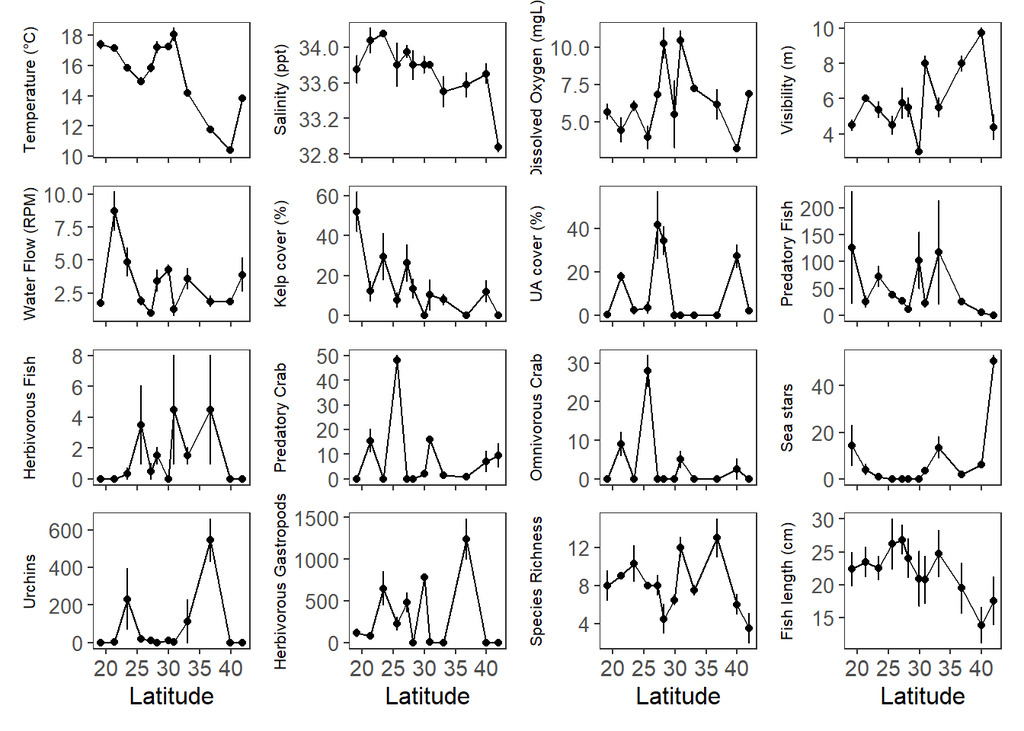

```r
Temperature_plot + Salinity_plot + Oxygen_plot + Visibility_plot+ RPM_plot + Kelp_plot + Understorey_algae_plot + PredatoryFish_plot + HerbivorousFish_plot + PredatoryCrab_plot + OmnivorousCrab_plot + Sea_star_plot + Urchin_plot + HerbGastropod_plot + Richness_plot + Size_plot + plot_layout(ncol=4)
```

Figure S1: Latitudinal variation of explanatory variables. Environmental variables are temperature (°C), salinity (ppt), dissolved oxygen (mgL), visibility (m) water flow (RPM). Kelp cover and Understorey algae (UA) cover correspond to benthic cover (%). Predatory fish, herbivorous fish, predatory crab, omnivorous crab, sea stars, urchins and herbivorous gastropods are mean abundances (number of individuals). Species richness corresponds to the number of species and fish length (cm) is an estimated size. Error bars represent standard error